# Работа с API AppsFlyer на R

```r
library(rappsflyer)
```

# Авторизационный токен

Для работы с API AppsFlyer вам необходимо получить авторизационный токен. Более подробно об этом можно узнать в этой [статье](https://support.appsflyer.com/hc/en-us/articles/360004562377).

Если в кратце то администраторы могут выдавать пользователям токены.

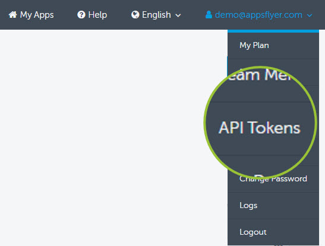

Где найти авторизационный токен

После того как вам выдали авторизационный токен вы можете установить его в своей R сессии функцией `af_set_api_token()`, передав в качестве единственного аргумента ваш API токен.

Так же вы можете сохранить токен в переменной среды `APPSFLYER_API_TOKEN`, в таком случае при загрузке пакета токен будет прочитан автоматически.

В каждой из функций можно отдельно указывать ваш токен используя аргумент `api_token`, но я не рекомендую хранить токен в коде, это является не лучшей практикой.

# Приложение по которому вы запрашиваете данные

В каждой из функций есть аргумент `app_id` в который необходимо передавать id вашего приложения, найти id можно в интерфейсе AppsFlyer.

[figure not shown]

Где найти ID приложения

# Запрос данных из API AppsFlyer

После того как установили свой API token вы можете запрашивать данные из Pull API. Для большего понимания структуры пакета `rappsflyer` вы можете перейти в интерфейсе AppsFlyer в Интеграции > API Доступ.

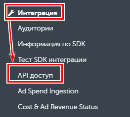

API Доступ

Каждая из функций пакета соответвует определённому разделу API доступа.

## Агрегированные данные (Aggregate (user acquisition and retargeting))

Для работы с агрегированными отчётами используйте функцию `af_get_aggregate_data()`.

*Аргументы:*

- date_from - начальная дата
- date_to - конечная дата
- report_type - тип отчёта
  - partners_report - Партнеры (медиаисточник)
  - partners_by_date_report - Партнеры — по датам
  - daily_report - Ежедневно
  - geo_report - Геоданные
  - geo_by_date_report - Геоданные — по датам
- additional_fields - дополнительные поля отчёта
- media_source - фильтр по источнику
- attribution_touch_type - Установите этот параметр, чтобы получить ключевые показатели эффективности атрибуции (VTA). Например: `attribution_touch_type="impression"`
- currency - Валюта выручки и стоимость. Агрегированные отчеты Pull API всегда используют валюту приложения.
- timezone - Часовой пояс
- retargeting - Получить данные по конверсии ретаргетинга.

Официальная справка по получению агрегированных отчётов из API AppsFlyer доступна по [ссылке](https://support.appsflyer.com/hc/ru/articles/207034346-Pull-APIs-Pulling-AppsFlyer-Reports-by-APIs).

## Отчеты по сырым данным

Для получения сырых данных используйте функцию `af_get_raw_data()`.

Доступные в ней типы отчётов:

- installs_report
- in_app_events_report
- uninstall_events_report

Официальная справка по получению отчётов с сырыми данными из API AppsFlyer доступна по [ссылке](https://support.appsflyer.com/hc/en-us/articles/360007530258-Using-Pull-API-raw-data).

## Отчёты по рекламной прибыли

Для полученния этой группы отчётов используйте функцию `af_get_ad_revenue_raw_data()`.

[Ссылка](https://support.appsflyer.com/hc/ru/articles/217490046-Ad-revenue-attribution-guide#ad-revenue-raw-data) на официальную документацию.

## Группа отчётов по неудачным установкам и событиям

Для получения отчётов из данной группы используйте функцию `af_get_targeting_validation_rules()`.

Доступные типы отчётов:

- invalid_installs_report
- invalid_in_app_events_report